# Laporan Berita Acara Penyusunan VMTS 2023-2028 - S2 Statistika Terapan FMIPA Unpad

[figure not shown]

**S2 Statistika Terapan FMIPA Unpad** Laporan proses penyusunan VMTS 2023-2028

Lampiran Bukti

Laporan Berita Acara / Dokumentasi Kegiatan

# Penyusunan Visi, Misi, Tujuan, dan Strategi Program Studi

Program Studi Magister Statistika Terapan FMIPA Universitas Padjadjaran - periode VMTS 2023-2028. Laporan ini menyatukan naskah akademik, dokumen penugasan dan undangan, dokumentasi rapat luring/daring, keterlibatan Advisory Board, serta bukti kesinambungan pengembangan kurikulum dan penjaminan mutu.

**Proses utama** Januari-Mei 2023 **Forum terverifikasi** 31 Januari 2023 **Advisory Board** Prof. Henk Folmer - Groningen University **Konteks paralel** Persiapan akreditasi internasional ASIIN

01

## Catatan Validitas dan Status Bukti

Laporan ini disusun dengan pendekatan kehati-hatian: tanggal dan keputusan yang dinyatakan secara spesifik hanya digunakan apabila didukung dokumen primer. Naskah akademik sendiri menegaskan bahwa kronologi Januari-Mei 2023 merupakan rekonstruksi institusional dan perlu dipadankan dengan SK, undangan, daftar hadir, notulen, dan berita acara asli.

Terverifikasi Dokumen**SK Advisory Board 26 Januari 2023**

Terverifikasi Undangan**Rapat 31 Januari 2023, 09.00-12.00 WIB**

Kronologi Naskah**Januari-Mei 2023, lima tahap**

Konteks Program**Berjalan paralel dengan persiapan ASIIN**

**Penting:** informasi bahwa penyusunan VMTS berjalan berbarengan dengan persiapan akreditasi internasional ASIIN, komposisi tim inti lima orang, serta praktik penggabungan daftar hadir untuk agenda paralel berasal dari keterangan pengelola program studi yang diberikan untuk penyusunan laporan ini. Informasi tersebut dipisahkan secara eksplisit dari fakta yang bersumber langsung dari naskah akademik/arsip primer.

02

## Dasar Kegiatan dan Keterlibatan Advisory Board

Dokumen primer

### SK Advisory Board Departemen Statistika

Keputusan Dekan FMIPA Universitas Padjadjaran Nomor **066/UN6.D/Kep/FMIPA/2023**, ditetapkan pada **26 Januari 2023**, mengangkat Tim Advisory Board Departemen Statistika. Lampirannya mencantumkan **Prof. Henk Folmer** dari Faculty Spatial Sciences, Groningen University sebagai anggota Advisory Board.

Mandat Advisory Board mencakup pemberian nasihat terkait prioritas pendidikan dan implementasi OBE, bentuk pembelajaran, program akademik dan penelitian, kemitraan, reputasi nasional-internasional, serta umpan balik terkait alumni dan pasar kerja.

Tanggal terverifikasi

### Evaluasi Kurikulum bersama Advisory Board

Undangan Departemen Statistika Nomor **84/UN6.D.3.5/TU.01.00/2023** tertanggal **25 Januari 2023** menetapkan pertemuan pada:

- **Hari/tanggal:** Selasa, 31 Januari 2023
- **Waktu:** 09.00-12.00 WIB
- **Tempat:** Ruang Rapat Departemen Statistika
- **Agenda:** Evaluasi Kurikulum Advisory Board Departemen Statistika

Forum ini relevan sebagai titik awal evaluasi dan pengumpulan masukan untuk memastikan arah program, kurikulum, capaian lulusan, dan VMTS saling konsisten.

03

## Tim Inti yang Ditugaskan

Untuk kepentingan laporan ini, tim inti penyusunan dicatat sesuai penugasan yang disampaikan oleh pengelola Program Studi. Tim bekerja melalui rapat luring, koordinasi daring, telaah dokumen, penyusunan draf, konsultasi, dan penyempurnaan rumusan.

1

**Dr. I Gede Nyoman Mindra Jaya, M.Si**Koordinator / tim inti penyusunan

2

**Dr. Bertho Tantular, M.Si**Tim inti penyusunan

3

**Dr. Irlandia Ginanjar, M.Si**Tim inti penyusunan dan pimpinan Departemen pada periode proses

4

**Dr. Gumgum Darmawan, M.Si**Tim inti penyusunan

5

**Dr. Anindya Apriliyanti Pravitasari, M.Si**Tim inti penyusunan

**Catatan rekonsiliasi dokumen:** naskah akademik yang dilampirkan memuat daftar personel yang lebih luas dan secara eksplisit meminta agar nomor SK, pembagian peran, serta nomenklatur jabatan dicocokkan dengan SK asli. Karena itu, laporan ini menggunakan lima nama di atas sebagai *tim inti yang ditugaskan* berdasarkan informasi terbaru yang diberikan, tanpa menghapus fakta bahwa peserta/kontributor proses lebih luas.

04

## Kronologi Penyusunan VMTS Januari-Mei 2023

Naskah akademik membagi proses menjadi lima tahap. Tidak semua tanggal harian tersedia dalam dokumen sumber; karenanya, selain forum 31 Januari 2023 yang didukung undangan, aktivitas berikut disajikan pada tingkat bulan.

Januari 2023 - Persiapan

**Mandat, tim, sumber rujukan, dan rencana kerja.**

Tahap awal mencakup penetapan mandat, pembentukan/koordinasi tim, telaah visi-misi Unpad dan FMIPA, inventarisasi regulasi, data awal, serta mekanisme kerja. SK Advisory Board tanggal 26 Januari dan undangan rapat tanggal 31 Januari menjadi bukti primer penting pada fase ini.

Februari 2023 - Evaluasi dan Pengumpulan Informasi

**Menilai relevansi rumusan lama dan kebutuhan pemangku kepentingan.**

Evaluasi diarahkan pada perkembangan keilmuan, kebutuhan lulusan, arah institusi, pembelajaran, benchmarking, tracer study, serta masukan internal/eksternal yang dapat diverifikasi.

Maret 2023 - Perumusan

**Mengubah masukan menjadi alternatif rumusan yang terstruktur.**

Tim mengelompokkan masukan ke dalam tema keunggulan akademik, riset, rekognisi internasional, dampak masyarakat, fokus bidang aplikasi, kerja sama, publikasi, dan tata kelola. Alternatif rumusan diuji dari sisi kejelasan, relevansi, diferensiasi, daya ingat, keterukuran turunan, dan konsistensi istilah. Analisis SWOT digunakan untuk menghubungkan kondisi program dengan strategi.

April 2023 - Konsultasi dan Penyempurnaan

**Uji keselarasan, konsultasi, revisi, dan penguatan indikator.**

Draf dibahas melalui forum internal dan konsultasi dengan pemangku kepentingan yang dapat diverifikasi. Kegiatan memanfaatkan perangkat kerja digital dan dapat berlangsung secara luring maupun daring. Masukan digunakan untuk menyempurnakan rumusan dan hubungan antara visi, misi, tujuan, strategi, serta indikator pencapaian.

Mei 2023 - Finalisasi, Penetapan, dan Sosialisasi

**Memastikan konsistensi dan menyiapkan implementasi.**

Tahap final memastikan konsistensi VMTS, indikator, dan periode pencapaian. Setelah validasi, rumusan diarahkan untuk ditetapkan melalui kewenangan institusional dan disosialisasikan melalui website, pedoman akademik, rapat dosen, orientasi mahasiswa, media visual, kegiatan penerimaan mahasiswa, dan dokumen kurikulum.

05

## Penyusunan VMTS dalam Konteks Persiapan Akreditasi Internasional ASIIN

Menurut keterangan pengelola program studi, proses penyusunan dan penguatan VMTS berlangsung berbarengan dengan persiapan akreditasi internasional ASIIN. Kondisi ini menjelaskan mengapa sejumlah rapat, bahan kerja, dan daftar hadir dapat mencakup lebih dari satu agenda dalam satu paket kegiatan.

Secara substantif, kedua proses tersebut saling memperkuat. Penyusunan VMTS membutuhkan kejelasan arah, keterukuran tujuan, keselarasan kurikulum, outcome pembelajaran, bukti keterlibatan stakeholder, internasionalisasi, dan mekanisme mutu. Pada saat yang sama, persiapan akreditasi internasional mendorong program studi untuk memperjelas hubungan antara profil lulusan, learning outcomes, kurikulum, penelitian, jejaring, dan sistem penjaminan mutu.

**Implikasi dokumentasi:** daftar hadir yang digunakan untuk rapat persiapan ASIIN dan pembahasan VMTS dapat berada dalam satu arsip kegiatan. Laporan ini tidak memisahkan peserta secara artifisial apabila dokumen primer memang merekam agenda sebagai rangkaian kerja yang terintegrasi.

### Benang merah VMTS - Kurikulum - ASIIN

- Profil lulusan dan capaian pembelajaran.
- Outcome-Based Education (OBE).
- Kurikulum berbasis riset dan kebutuhan stakeholder.
- Keterukuran tujuan dan strategi.
- Rekognisi dan jejaring internasional.
- Budaya bukti dan quality assurance.
- Integrasi penelitian, publikasi, dan dampak masyarakat.

Keterlibatan Advisory Board, termasuk Prof. Henk Folmer, memberi perspektif eksternal/internasional dalam evaluasi arah akademik dan pengembangan program.

06

## Hasil Substantif Penyusunan

### Visi Program Studi

**Menjadi pusat pendidikan Magister Statistika yang unggul dalam pendidikan dan riset, diakui secara internasional, serta memberikan dampak nyata bagi masyarakat, khususnya dalam bidang statistika bisnis dan industri, statistika sosial, aktuaria, biostatistika, dan sains data.**

### Misi

1. Menyelenggarakan pendidikan dan pembelajaran Magister Statistika dengan fokus pada pengembangan dan penerapan statistika di bidang bisnis industri, sosial, aktuaria, biostatistika, dan sains data.
2. Melaksanakan penelitian yang mendukung pengembangan statistika dan memberikan dampak positif bagi masyarakat.
3. Menjalin kerja sama dalam bidang pendidikan dan penelitian dengan berbagai pihak di tingkat nasional maupun internasional.
4. Mempublikasikan hasil-hasil penelitian dalam bentuk publikasi ilmiah bereputasi.

### Tujuan

1. Mengembangkan statistika dan mengaplikasikannya melalui riset berkualitas untuk memecahkan masalah dunia nyata.
2. Memecahkan masalah statistika melalui pendekatan interdisipliner atau multidisipliner.
3. Mengelola riset serta membangun kerja sama berkelanjutan dengan industri, pemerintah, dan lembaga penelitian.
4. Mengomunikasikan ide secara jelas, bekerja profesional, serta memiliki etika dan tanggung jawab tinggi.

### Strategi Pencapaian

1. Peningkatan kualitas lulusan, kurikulum, dan mutu program studi.
2. Pengembangan kurikulum berbasis riset, fasilitas, jejaring nasional-internasional, dan reputasi.
3. Peningkatan kapasitas dan kolaborasi riset dengan industri, pemerintah, dan lembaga penelitian.
4. Penguatan keterampilan menulis/presentasi ilmiah, etika, integritas akademik, dan akses literatur.

07

## Matriks Jejak Bukti

| Bukti | Waktu | Fungsi dalam laporan | Status |
| --- | --- | --- | --- |
| Naskah Akademik Penyusunan VMTS | Januari-Mei 2023 / disusun Mei 2023 | Dasar metodologi, kronologi, substansi, implementasi, dan monev. | Terverifikasi |
| SK Advisory Board No. 066/UN6.D/Kep/FMIPA/2023 | 26 Januari 2023 | Dasar formal Advisory Board dan keterlibatan Prof. Henk Folmer. | Terverifikasi |
| Undangan No. 84/UN6.D.3.5/TU.01.00/2023 | 31 Januari 2023 | Bukti forum evaluasi kurikulum Advisory Board, 09.00-12.00 WIB. | Terverifikasi |
| Aktivitas Februari-April 2023 | Per bulan | Evaluasi, pengumpulan informasi, perumusan, konsultasi, penyempurnaan. | Rekonstruksi naskah |
| Finalisasi dan sosialisasi | Mei 2023 | Konsistensi rumusan, pengesahan, media sosialisasi dan implementasi. | Rekonstruksi naskah |
| Keterangan proses paralel ASIIN | Selama proses kerja terkait | Menjelaskan integrasi agenda dan penggunaan paket daftar hadir yang sama. | Keterangan pengelola |
| SK/undangan peninjauan kurikulum 2024 | April 2024 | Bukti kesinambungan review pasca-penetapan VMTS. | Tindak lanjut |
| Daftar hadir Google Drive | Sesuai arsip Drive | Bukti partisipasi rapat/agenda terintegrasi VMTS-ASIIN. | Tautan tersedia; belum tertanam |

08

## Dokumentasi Foto Kegiatan

Foto digunakan untuk menunjukkan bentuk proses kerja: diskusi luring, rapat tim, pembahasan profil lulusan dan learning outcomes, konsultasi daring dengan Advisory Board, serta kesinambungan penguatan akreditasi. Kecuali terdapat penanda tanggal yang jelas pada foto/dokumen primer, laporan tidak menggunakan foto untuk menetapkan tanggal spesifik.

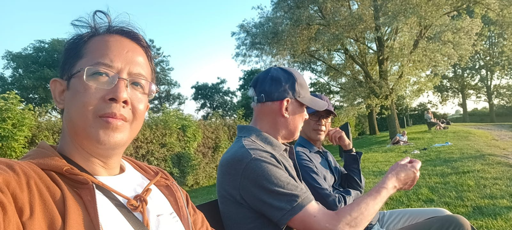

**Diskusi informal bersama Advisory Board**  
Dokumentasi interaksi langsung dengan Advisory Board. Tanggal spesifik foto tidak digunakan sebagai dasar kronologi.

[figure not shown]

**Rapat kerja tim**  
Dokumentasi rapat kerja tim dalam pembahasan substansi akademik dan pengembangan program.

[figure not shown]

**Pembahasan profil lulusan dan LO**  
Dokumentasi pembahasan profil lulusan/learning outcomes yang terkait dengan penerjemahan VMTS ke kurikulum.

[figure not shown]

**Penyelarasan kurikulum dan capaian**  
Dokumentasi penyelarasan profil lulusan, capaian pembelajaran, dan arah akademik program.

[figure not shown]

**Forum konsultasi dan pembahasan**  
Dokumentasi forum yang melibatkan dosen/mahasiswa dalam diskusi akademik. Tanggal spesifik perlu dipadankan dengan arsip daftar hadir.

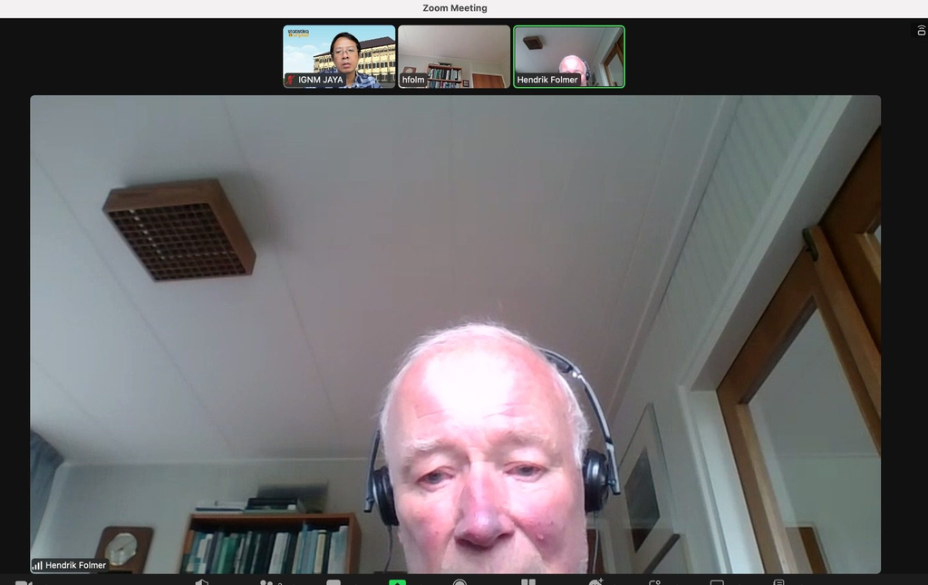

**Konsultasi daring dengan Prof. Henk Folmer**  
Dokumentasi konsultasi daring melalui Zoom dengan Prof. Henk Folmer dari Groningen University.

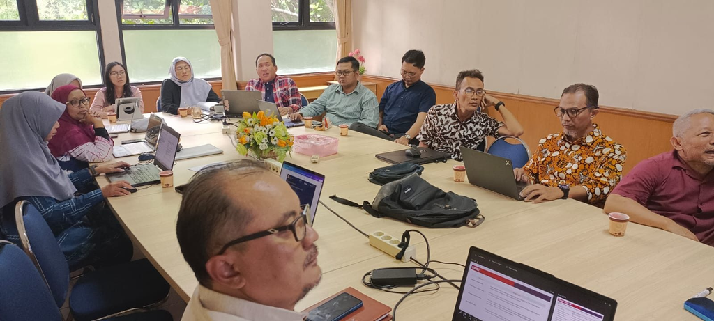

**Rapat departemen / penguatan dokumen**  
Dokumentasi pembahasan di Ruang Rapat Departemen Statistika sebagai bagian dari penguatan tata kelola dan dokumen akademik.

[figure not shown]

**Koordinasi daring tim dosen**  
Dokumentasi koordinasi daring dosen sebagai bagian dari proses diskusi dan penyelarasan.

[figure not shown]

**Kesinambungan persiapan akreditasi**  
Dokumentasi tahap lanjutan persiapan akreditasi. Foto ini bertanggal 15 Juli 2026 dan ditempatkan sebagai bukti kesinambungan, bukan sebagai bukti peristiwa 2023.

09

## Daftar Hadir / Absensi Rangkaian Kegiatan

### Arsip Google Drive

Pengelola program studi memberikan tautan daftar hadir yang digunakan sebagai bagian dari paket dokumentasi rapat persiapan VMTS dan akreditasi internasional ASIIN.

https://drive.google.com/file/d/12zsxu-DZBvxGzEMUZ6upJ6DKInVeXO6s/view?usp=sharing

**Status teknis:** tautan Drive tercatat, tetapi file tidak dapat diunduh secara otomatis dari lingkungan penyusunan laporan ini. Karena prinsip laporan adalah tidak mengarang bukti, daftar hadir belum dikonversi menjadi PNG di dalam file. Bila file absensi diunggah langsung ke percakapan, bagian ini dapat diganti menjadi lampiran PNG yang sepenuhnya self-contained.

[interactive chart not shown]

10

## Lampiran Dokumen - Seluruh PDF Dirender sebagai PNG

Sesuai kebutuhan dokumentasi, seluruh PDF yang dilampirkan pada penyusunan laporan ini ditampilkan kembali sebagai gambar PNG. Dokumen tahun 2024 ditempatkan sebagai bukti kesinambungan peninjauan kurikulum dan mutu, bukan sebagai bukti inti kronologi penyusunan Januari-Mei 2023.

**01 **Naskah Akademik Penyusunan VMTS 2023-2028**37 halaman PNG - Dokumen utama landasan, metodologi, kronologi Januari-Mei 2023, rumusan VMTS, implementasi, dan monitoring.**

[figure not shown]

Naskah Akademik Penyusunan VMTS 2023-2028 - halaman 1

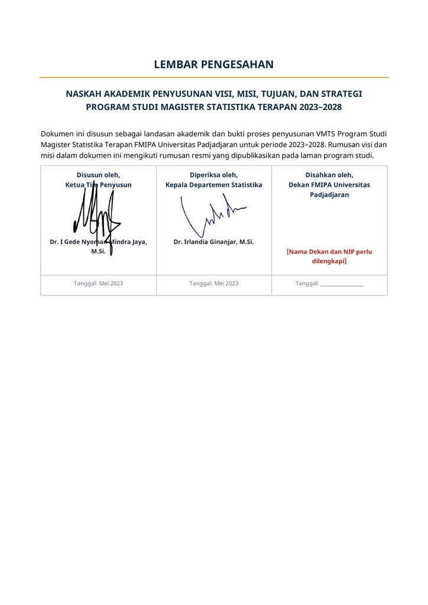

Naskah Akademik Penyusunan VMTS 2023-2028 - halaman 2

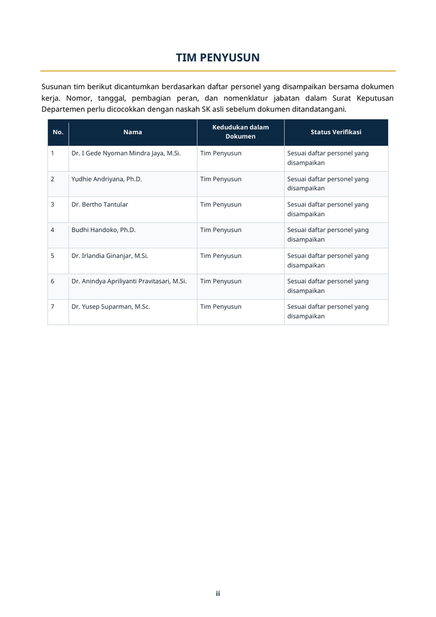

Naskah Akademik Penyusunan VMTS 2023-2028 - halaman 3

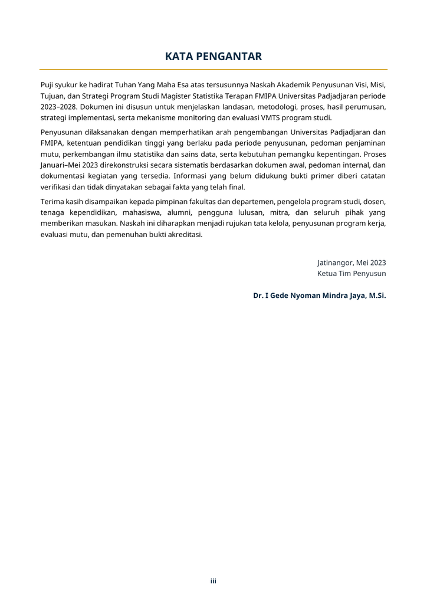

Naskah Akademik Penyusunan VMTS 2023-2028 - halaman 4

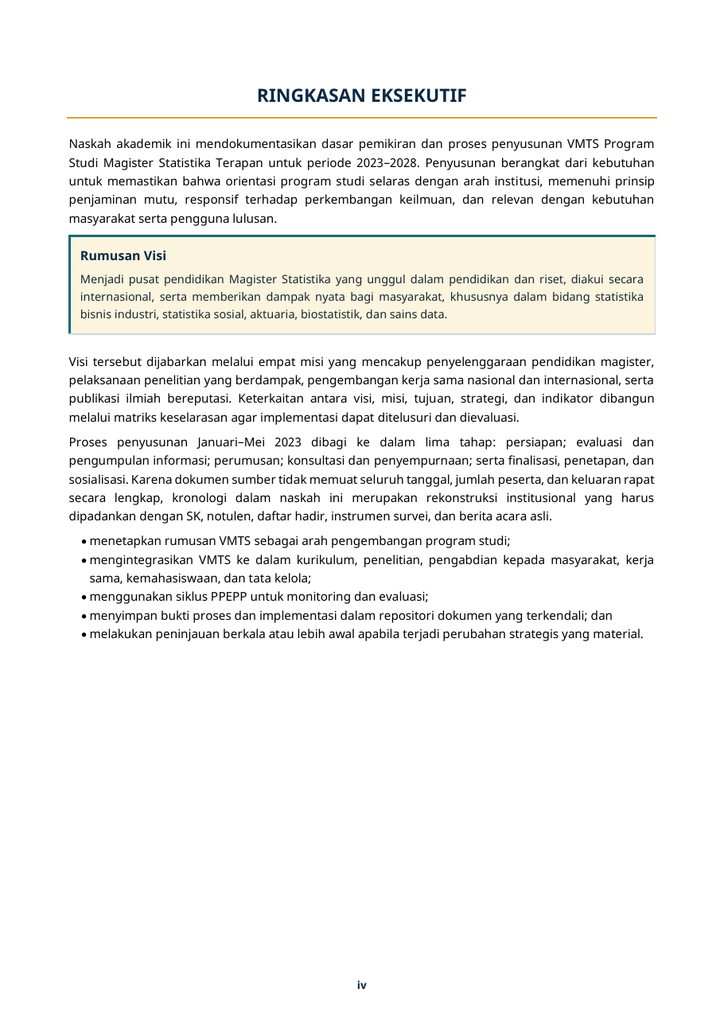

Naskah Akademik Penyusunan VMTS 2023-2028 - halaman 5

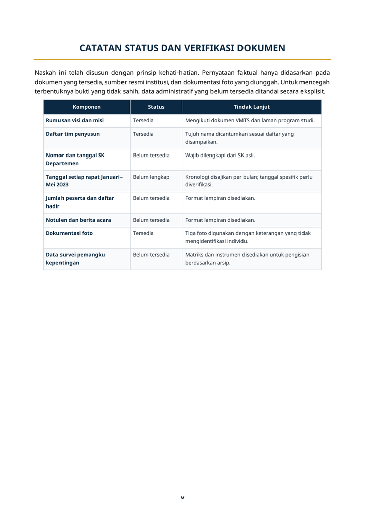

Naskah Akademik Penyusunan VMTS 2023-2028 - halaman 6

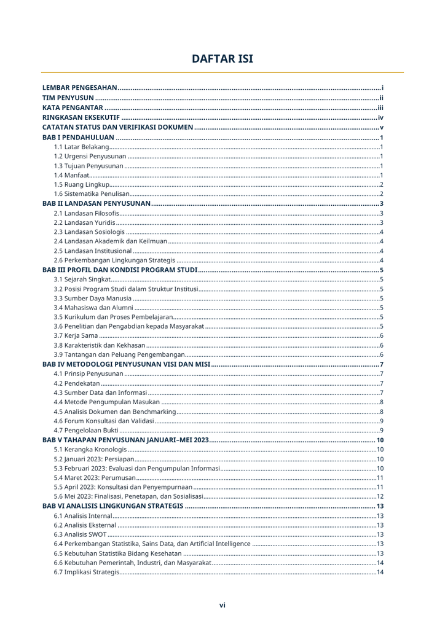

Naskah Akademik Penyusunan VMTS 2023-2028 - halaman 7

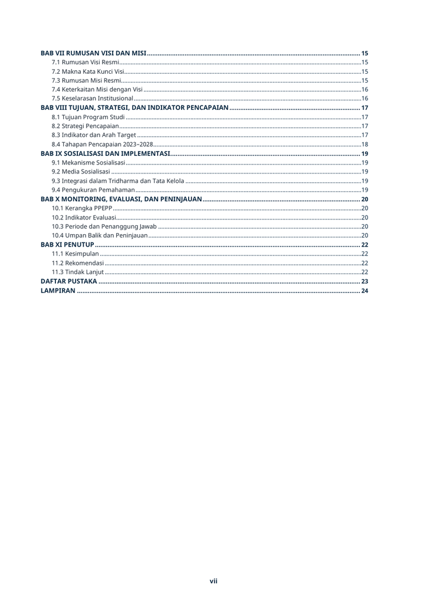

Naskah Akademik Penyusunan VMTS 2023-2028 - halaman 8

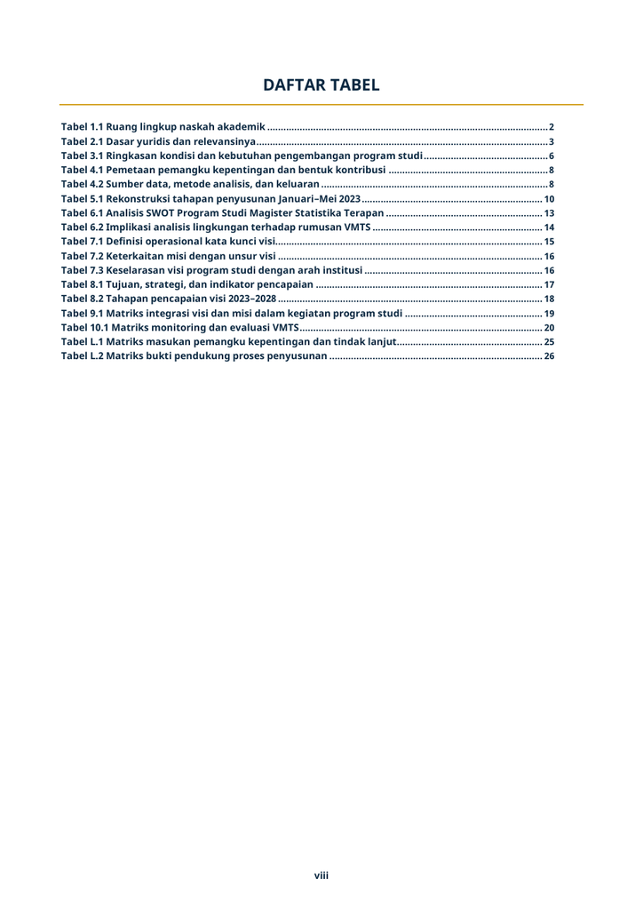

Naskah Akademik Penyusunan VMTS 2023-2028 - halaman 9

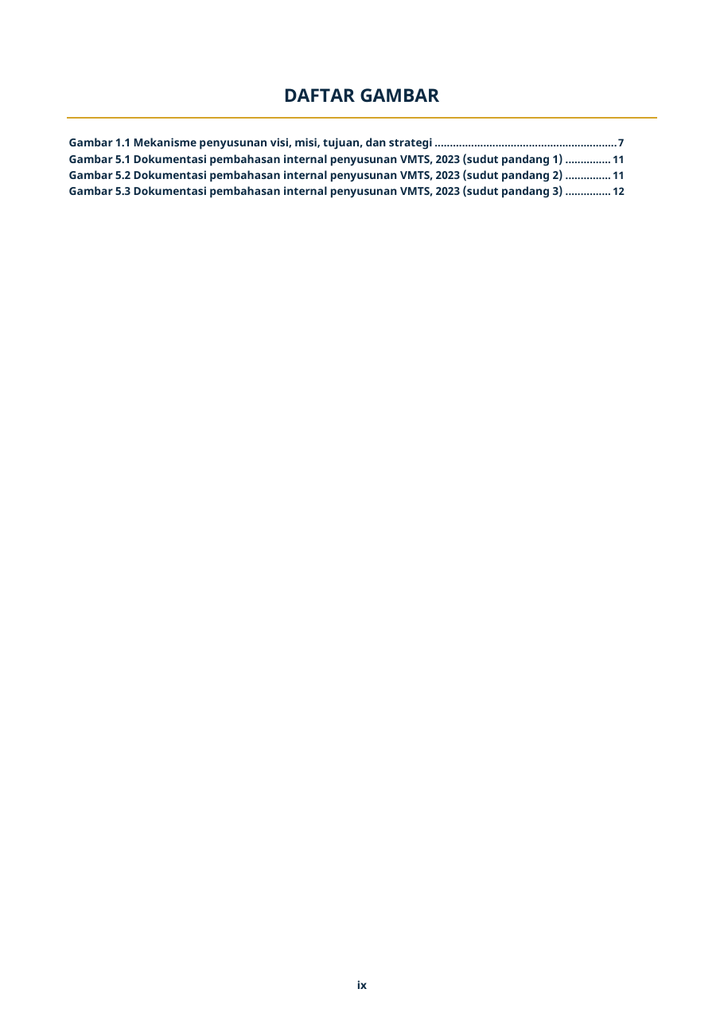

Naskah Akademik Penyusunan VMTS 2023-2028 - halaman 10

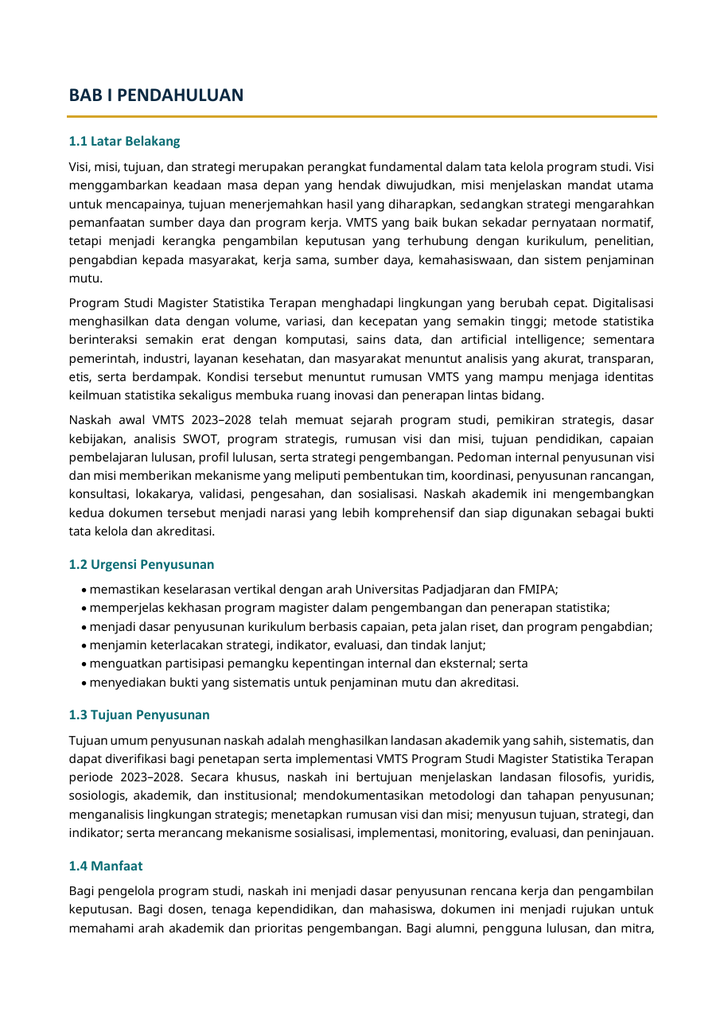

Naskah Akademik Penyusunan VMTS 2023-2028 - halaman 11

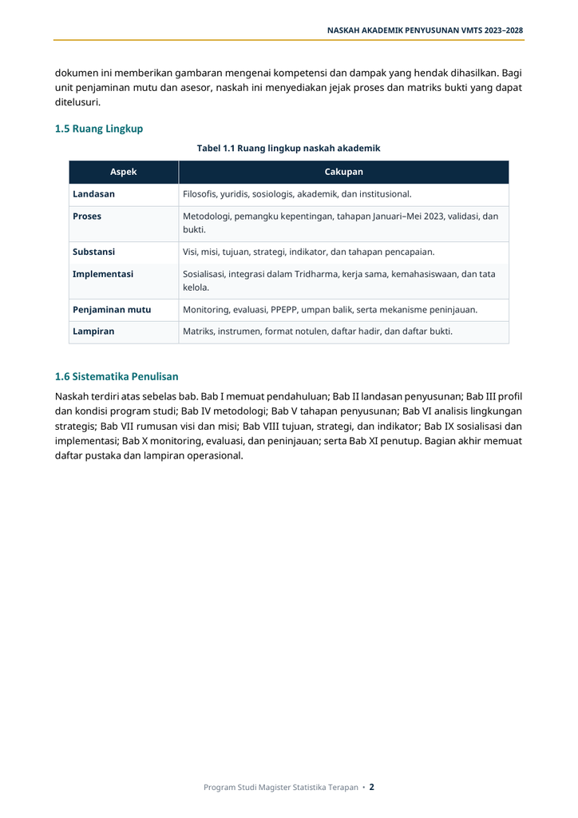

Naskah Akademik Penyusunan VMTS 2023-2028 - halaman 12

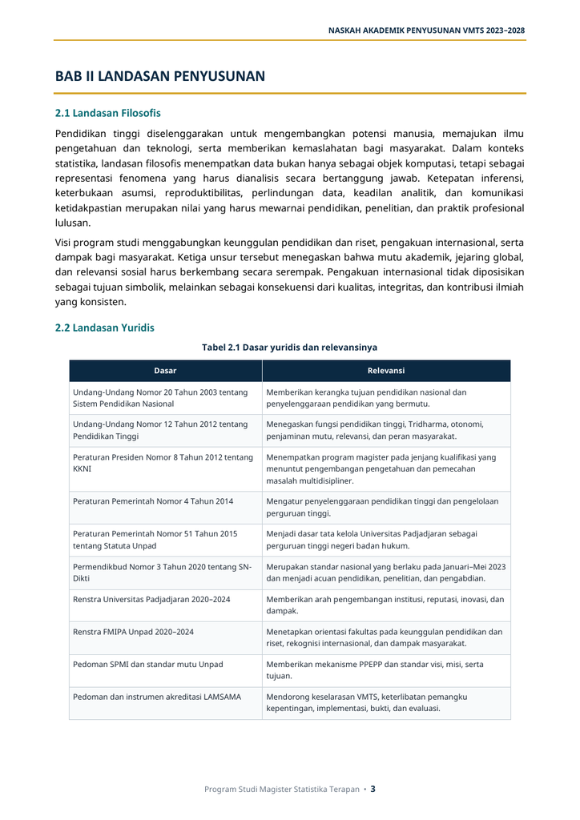

Naskah Akademik Penyusunan VMTS 2023-2028 - halaman 13

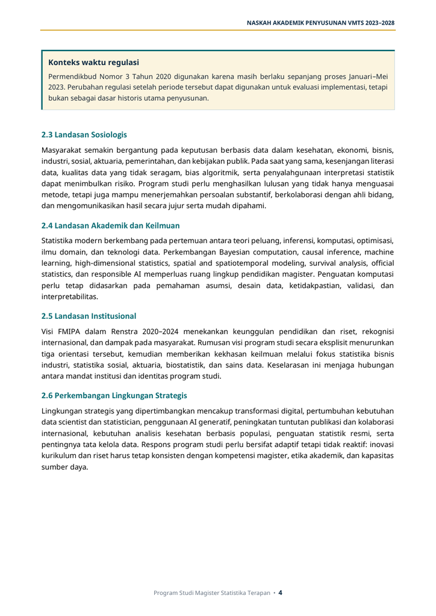

Naskah Akademik Penyusunan VMTS 2023-2028 - halaman 14

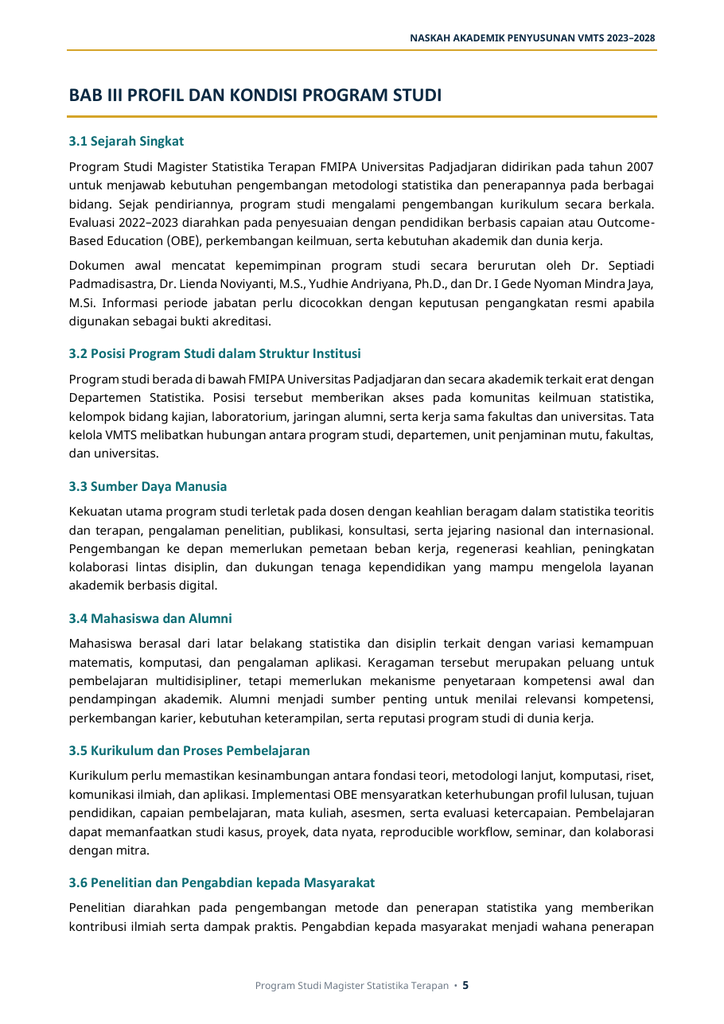

Naskah Akademik Penyusunan VMTS 2023-2028 - halaman 15

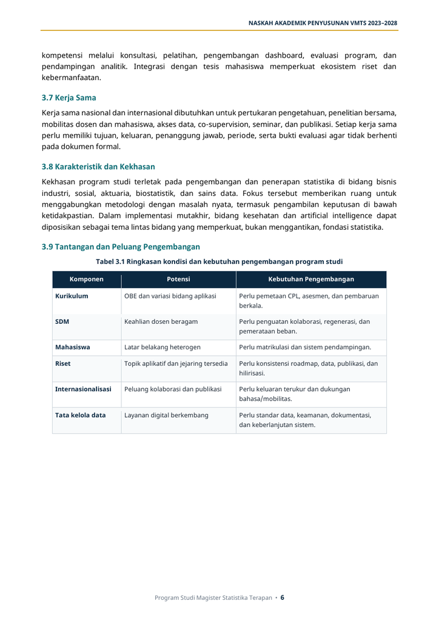

Naskah Akademik Penyusunan VMTS 2023-2028 - halaman 16

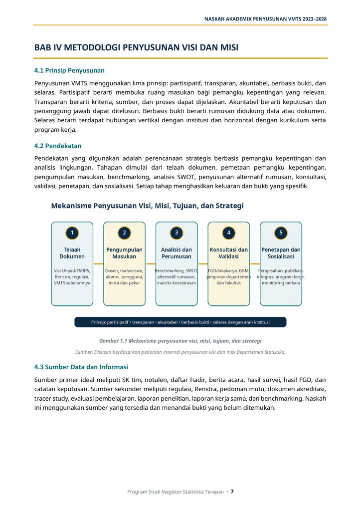

Naskah Akademik Penyusunan VMTS 2023-2028 - halaman 17

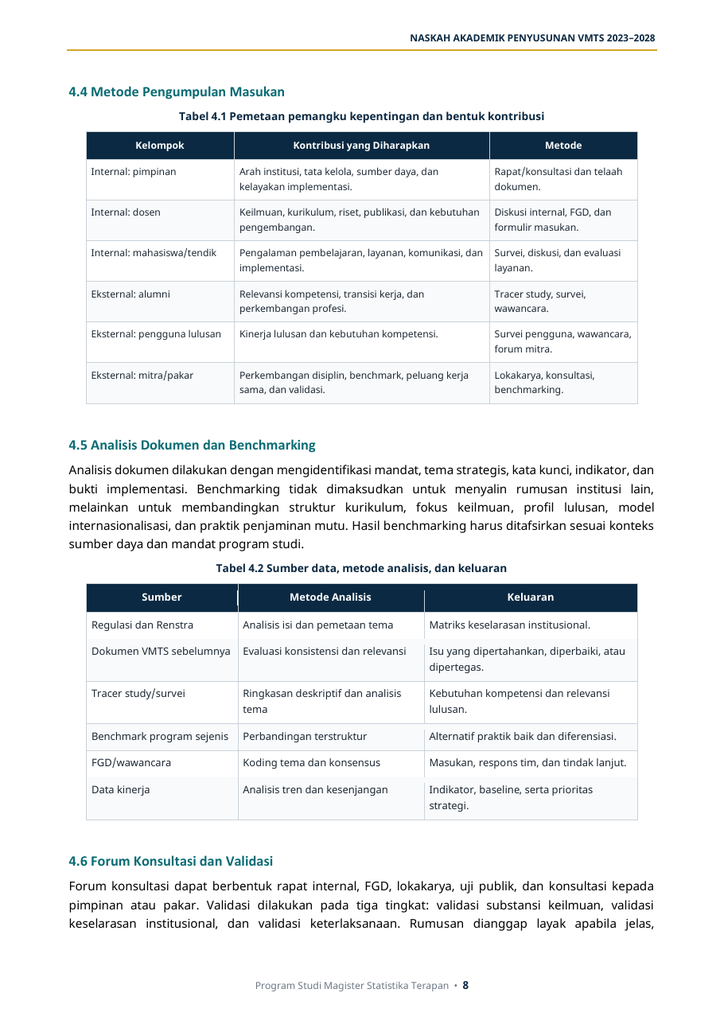

Naskah Akademik Penyusunan VMTS 2023-2028 - halaman 18

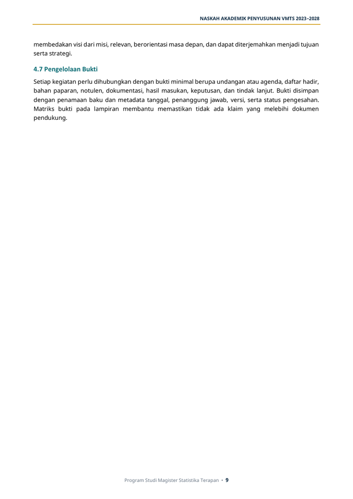

Naskah Akademik Penyusunan VMTS 2023-2028 - halaman 19

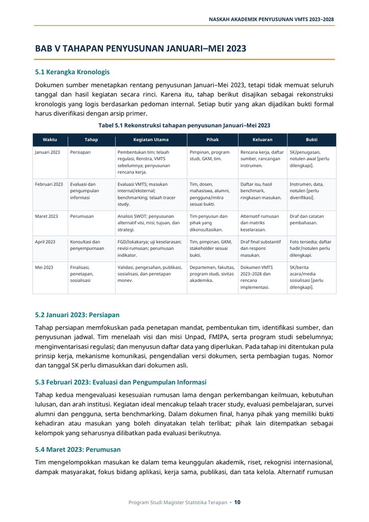

Naskah Akademik Penyusunan VMTS 2023-2028 - halaman 20

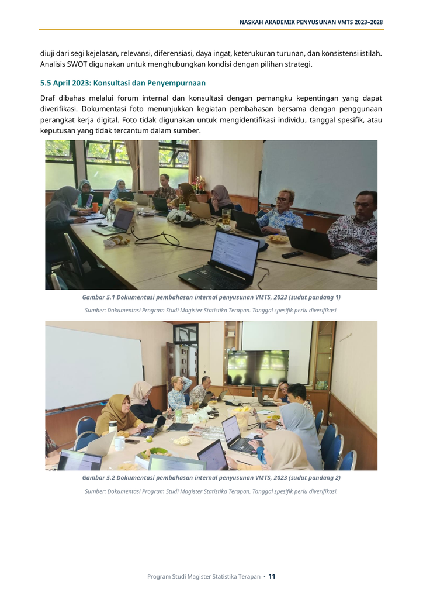

Naskah Akademik Penyusunan VMTS 2023-2028 - halaman 21

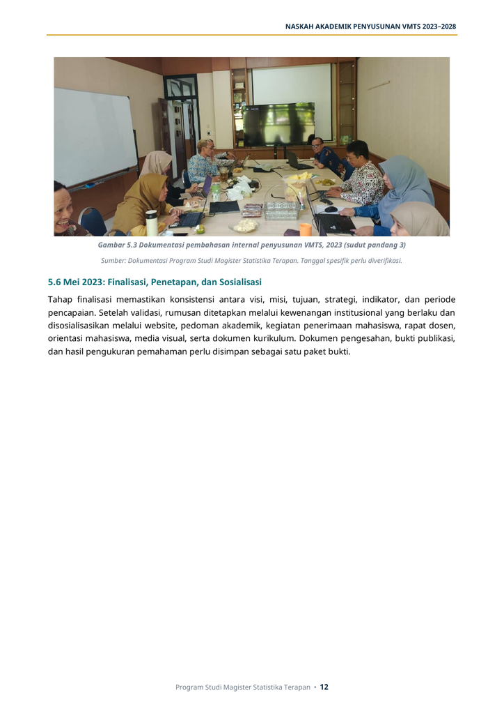

Naskah Akademik Penyusunan VMTS 2023-2028 - halaman 22

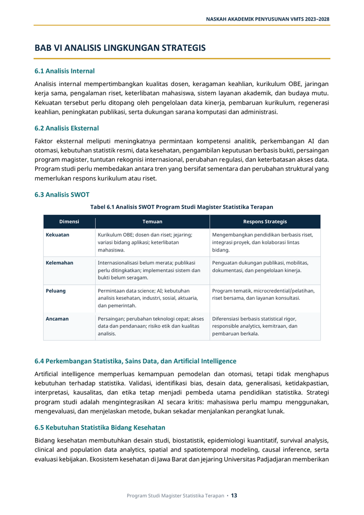

Naskah Akademik Penyusunan VMTS 2023-2028 - halaman 23

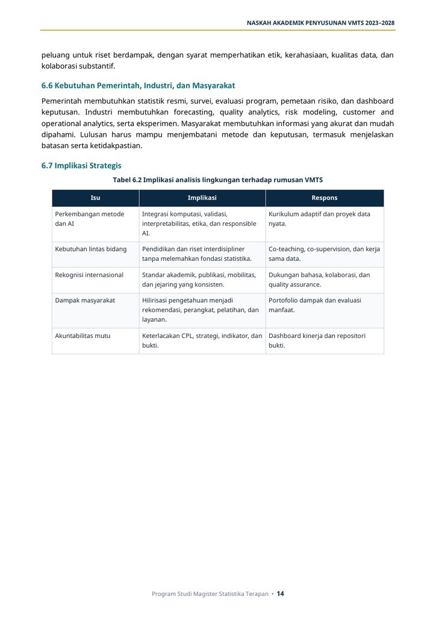

Naskah Akademik Penyusunan VMTS 2023-2028 - halaman 24

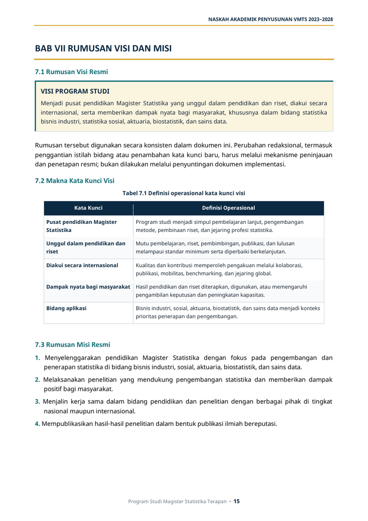

Naskah Akademik Penyusunan VMTS 2023-2028 - halaman 25

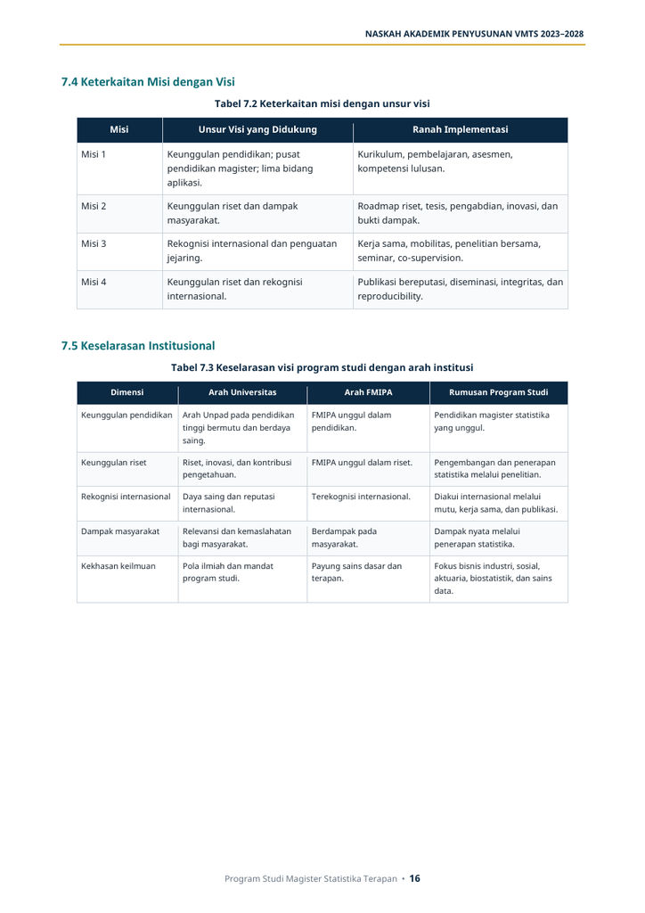

Naskah Akademik Penyusunan VMTS 2023-2028 - halaman 26

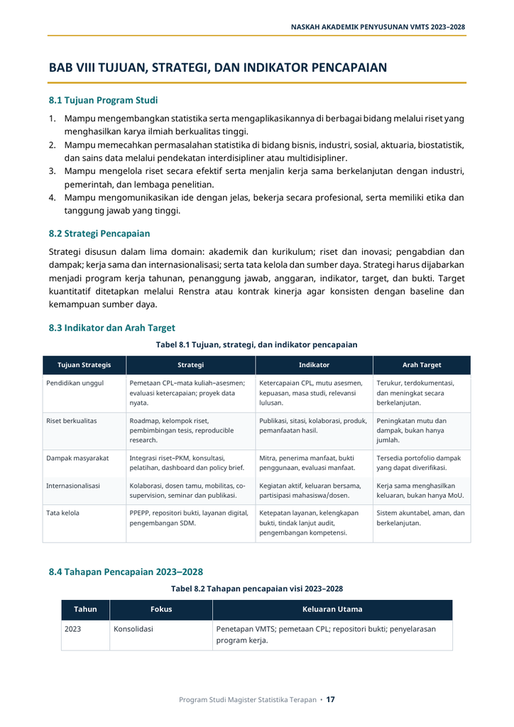

Naskah Akademik Penyusunan VMTS 2023-2028 - halaman 27

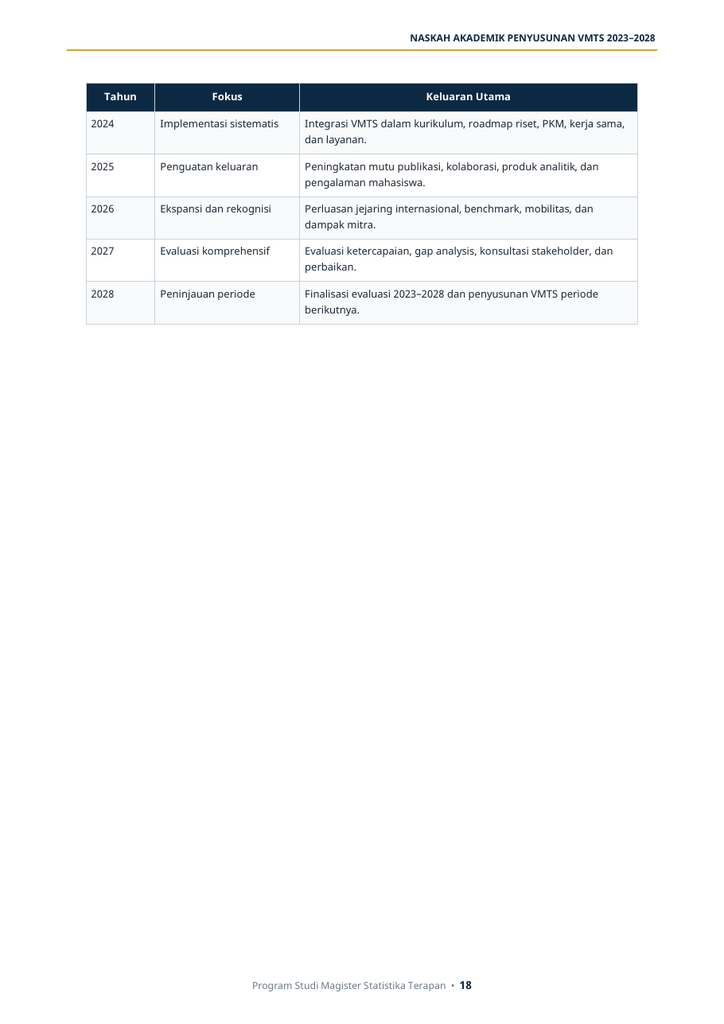

Naskah Akademik Penyusunan VMTS 2023-2028 - halaman 28

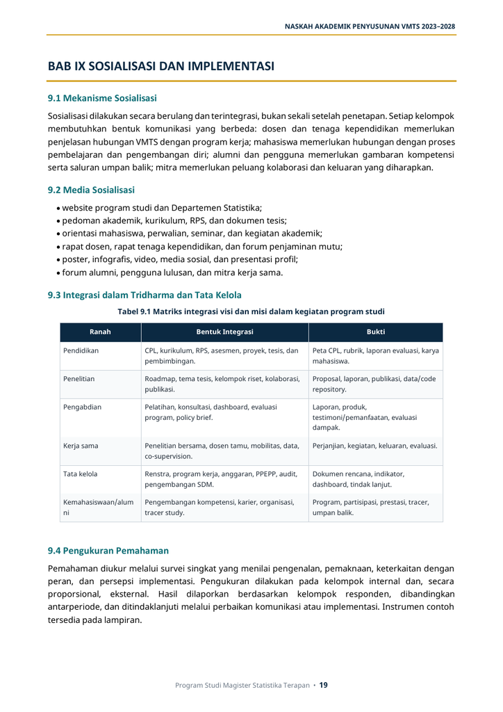

Naskah Akademik Penyusunan VMTS 2023-2028 - halaman 29

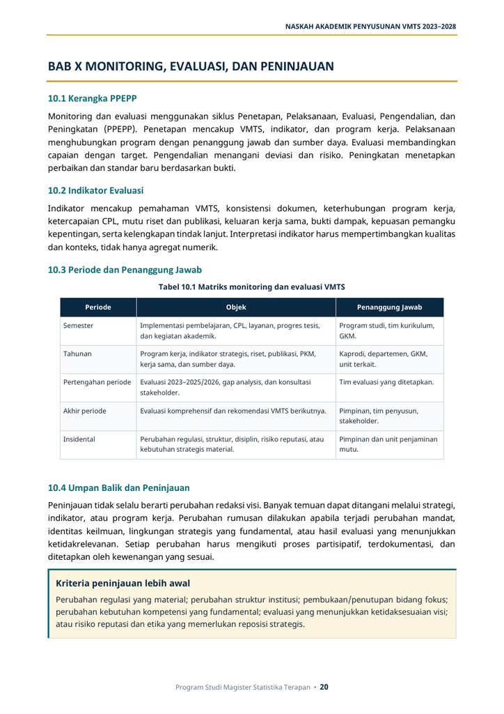

Naskah Akademik Penyusunan VMTS 2023-2028 - halaman 30

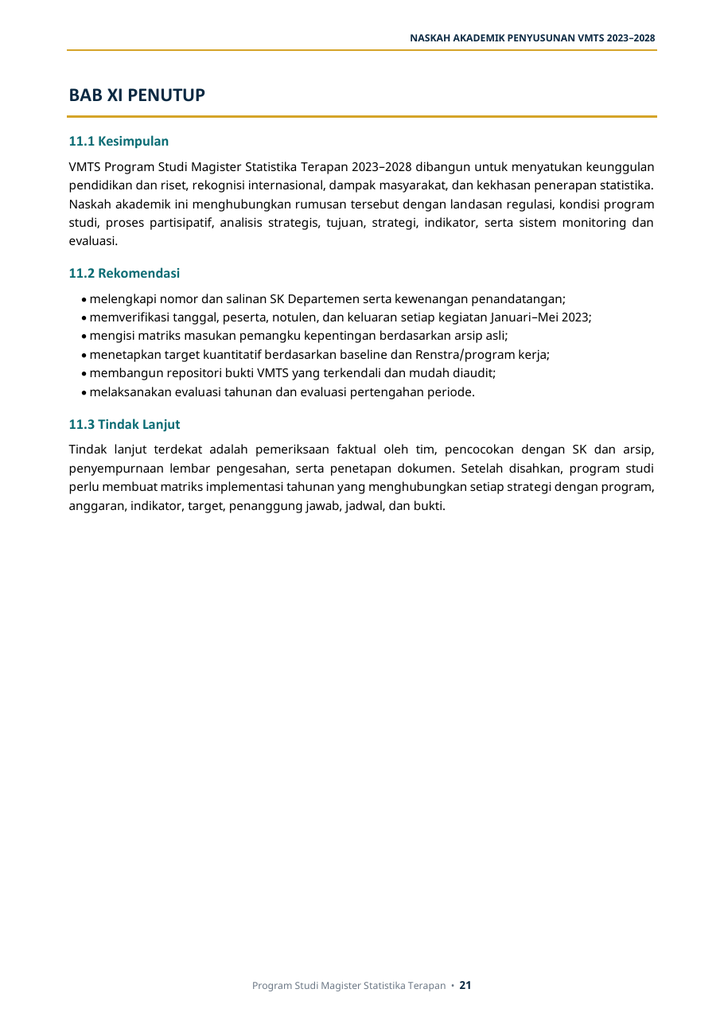

Naskah Akademik Penyusunan VMTS 2023-2028 - halaman 31

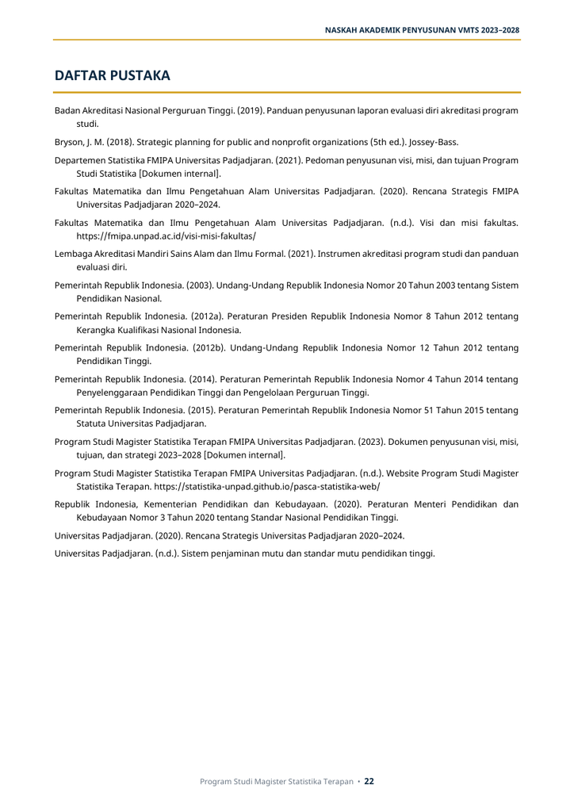

Naskah Akademik Penyusunan VMTS 2023-2028 - halaman 32

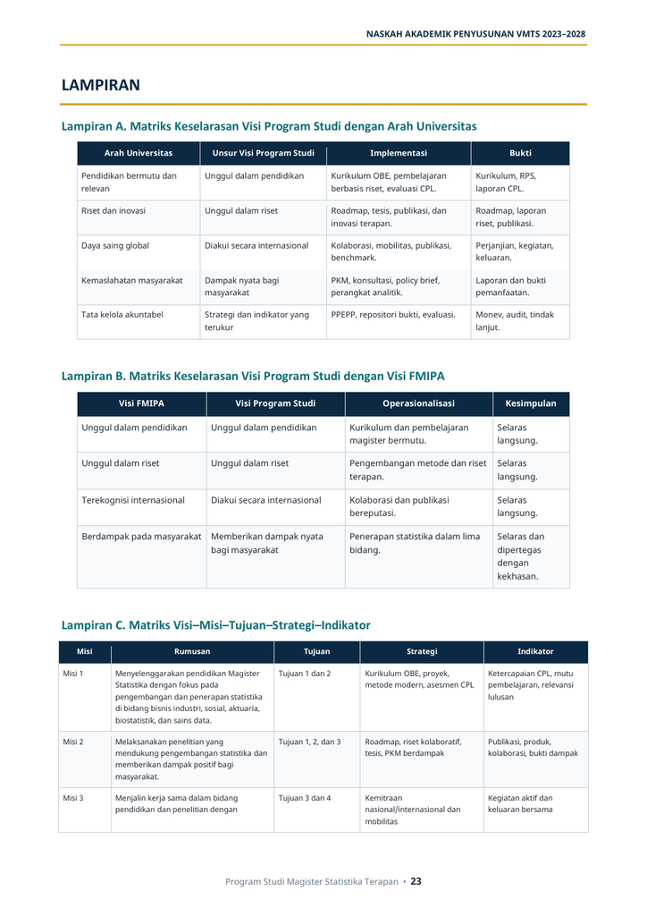

Naskah Akademik Penyusunan VMTS 2023-2028 - halaman 33

[figure not shown]

Naskah Akademik Penyusunan VMTS 2023-2028 - halaman 34

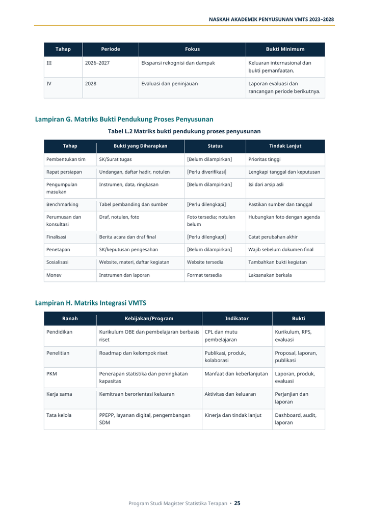

Naskah Akademik Penyusunan VMTS 2023-2028 - halaman 35

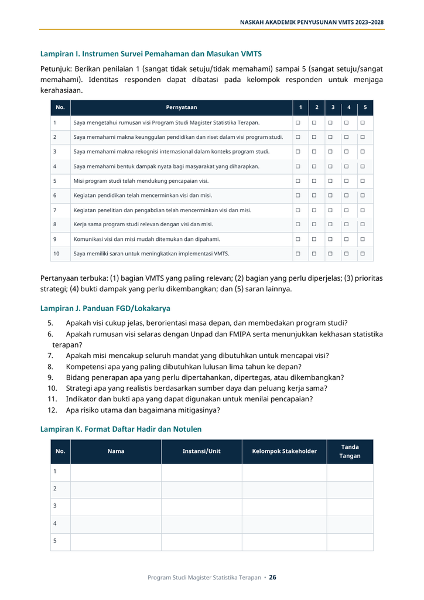

Naskah Akademik Penyusunan VMTS 2023-2028 - halaman 36

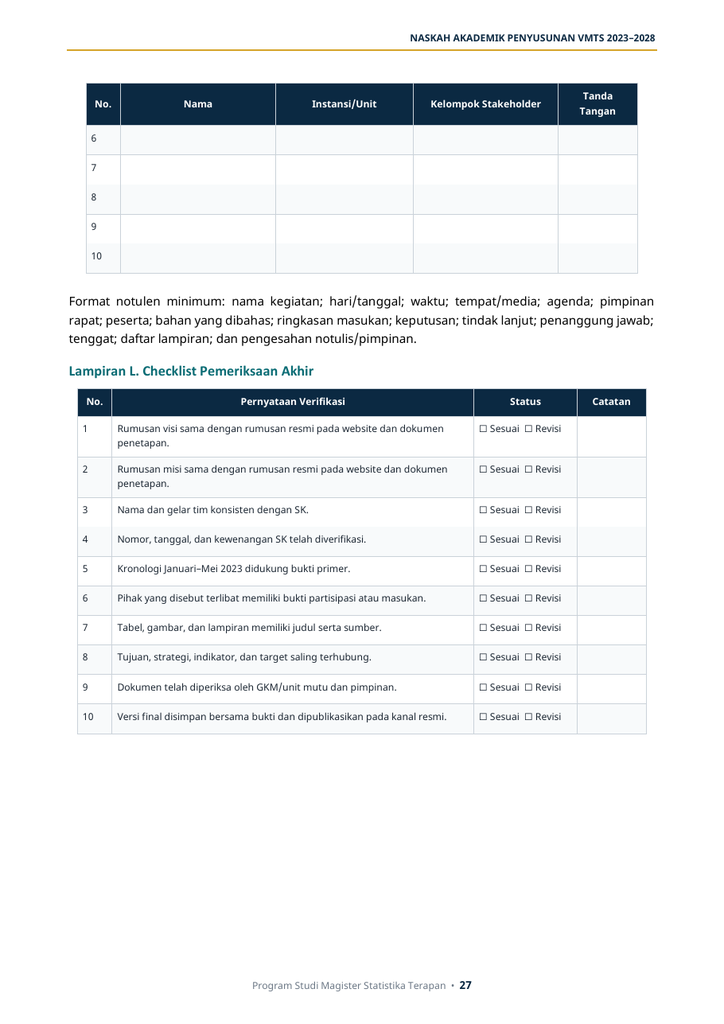

Naskah Akademik Penyusunan VMTS 2023-2028 - halaman 37

**02 **SK Advisory Board Departemen Statistika 2023**3 halaman PNG - Keputusan Dekan FMIPA Unpad No. 066/UN6.D/Kep/FMIPA/2023; memuat pengangkatan Advisory Board, termasuk Prof. Henk Folmer.**

[figure not shown]

SK Advisory Board Departemen Statistika 2023 - halaman 1

[figure not shown]

SK Advisory Board Departemen Statistika 2023 - halaman 2

[figure not shown]

SK Advisory Board Departemen Statistika 2023 - halaman 3

**03 **Undangan Evaluasi Kurikulum Advisory Board - 31 Januari 2023**1 halaman PNG - Undangan No. 84/UN6.D.3.5/TU.01.00/2023 untuk evaluasi kurikulum bersama Advisory Board.**

[figure not shown]

Undangan Evaluasi Kurikulum Advisory Board - 31 Januari 2023 - halaman 1

**04 **SK Tim Ad Hoc Redesain Kurikulum 2024**3 halaman PNG - Dokumen tindak lanjut tahun 2024; ditempatkan sebagai bukti kesinambungan peninjauan kurikulum, bukan bukti inti formulasi Januari-Mei 2023.**

[figure not shown]

SK Tim Ad Hoc Redesain Kurikulum 2024 - halaman 1

[figure not shown]

SK Tim Ad Hoc Redesain Kurikulum 2024 - halaman 2

[figure not shown]

SK Tim Ad Hoc Redesain Kurikulum 2024 - halaman 3

**05 **Undangan Peninjauan Kurikulum - 22 April 2024**1 halaman PNG - Dokumen tindak lanjut peninjauan kurikulum 2024 untuk merespons perkembangan regulasi dan penjaminan mutu.**

[figure not shown]

Undangan Peninjauan Kurikulum - 22 April 2024 - halaman 1

## Berita Acara dan Kesimpulan

Proses tersebut tidak berdiri sendiri. Evaluasi kurikulum bersama Advisory Board pada 31 Januari 2023, keterlibatan Prof. Henk Folmer dari Groningen University, diskusi luring dan daring, pengujian keterkaitan profil lulusan dan learning outcomes, serta penyiapan bukti penjaminan mutu menunjukkan bahwa penyusunan VMTS ditempatkan dalam kerangka pengembangan program yang lebih luas.

Berdasarkan keterangan pengelola, rangkaian ini juga beririsan dengan persiapan akreditasi internasional ASIIN. Oleh sebab itu, sejumlah rapat dan daftar hadir didokumentasikan sebagai satu paket agenda akademik dan penjaminan mutu. Pendekatan tersebut dinilai wajar sepanjang setiap klaim dalam laporan tetap dapat ditelusuri kepada dokumen, foto, daftar hadir, atau arsip primer yang relevan.

**Kesimpulan utama:** VMTS 2023-2028 disusun sebagai kerangka pengambilan keputusan akademik, bukan sekadar pernyataan normatif. Rumusan diarahkan agar terhubung dengan kurikulum, penelitian, pengabdian kepada masyarakat, kerja sama, publikasi, kemahasiswaan, internasionalisasi, dan sistem penjaminan mutu; implementasinya kemudian dipantau dan ditinjau secara berkala.

**Catatan penyusunan laporan**  
Laporan ini merupakan kompilasi dokumentatif berdasarkan naskah akademik, arsip yang diunggah, dokumentasi foto, dan keterangan pengelola program studi. Informasi yang belum mempunyai bukti primer lengkap ditandai secara eksplisit agar tidak membentuk klaim administratif yang tidak sahih.

Jatinangor, Agustus 2026

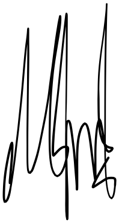

I Gede Nyoman Mindra Jaya Kaprodi S2 Statistika Terapan FMIPA UNPAD